# LSA group project (part 1 + 2)

2025-11-13

# PART 1: DATA EXPLORATION

## loading the data

```r
library(data.table)

df <- fread("GSE96058_expression_matrix.tsv")
meta <- read.delim("GSE96058_metadata.txt", header = TRUE)
```

## exploring the data

```r
# amount of samples (rows) and variables (columns)
dim(meta)
```

```
## [1] 3069   31
```

```r
# show first few rows
head(meta)
```

```
##    sample_id title geo_accession type channel_count      source_name_ch1
## 1 GSM2528079    F1    GSM2528079  SRA             1 Primary breast tumor
## 2 GSM2528080    F2    GSM2528080  SRA             1 Primary breast tumor
## 3 GSM2528081    F3    GSM2528081  SRA             1 Primary breast tumor
## 4 GSM2528082    F4    GSM2528082  SRA             1 Primary breast tumor
## 5 GSM2528083    F5    GSM2528083  SRA             1 Primary breast tumor
## 6 GSM2528084    F6    GSM2528084  SRA             1 Primary breast tumor
##   age.at.diagnosis.ch1 chemo.treated.ch1 endocrine.treated.ch1
## 1                   43                 1                     0
## 2                   48                 1                     1
## 3                   69                 1                     1
## 4                   39                 1                     1
## 5                   73                 0                     1
## 6                   40                 1                     0
##   er.prediction.mgc.ch1 er.prediction.sgc.ch1 er.status.ch1
```

[output cut: 55 more lines]

```r
# statistical summary (for numerics/factors)
summary(meta)
```

```
##   sample_id            title           geo_accession          type
##  Length:3069        Length:3069        Length:3069        Length:3069
##  Class :character   Class :character   Class :character   Class :character
##  Mode  :character   Mode  :character   Mode  :character   Mode  :character
##
##
##
##
##  channel_count source_name_ch1    age.at.diagnosis.ch1 chemo.treated.ch1
##  Min.   :1     Length:3069        Min.   :24.00        Min.   :0.0000
##  1st Qu.:1     Class :character   1st Qu.:53.00        1st Qu.:0.0000
##  Median :1     Mode  :character   Median :64.00        Median :0.0000
##  Mean   :1                        Mean   :62.76        Mean   :0.4072
##  3rd Qu.:1                        3rd Qu.:71.00        3rd Qu.:1.0000
##  Max.   :1                        Max.   :96.00        Max.   :1.0000
##                                                        NA's   :21
##  endocrine.treated.ch1 er.prediction.mgc.ch1 er.prediction.sgc.ch1
##  Min.   :0.0000        Min.   :0.0000        Min.   :0.0000
##  1st Qu.:1.0000        1st Qu.:1.0000        1st Qu.:1.0000
##  Median :1.0000        Median :1.0000        Median :1.0000
##  Mean   :0.7765        Mean   :0.7983        Mean   :0.8866
##  3rd Qu.:1.0000        3rd Qu.:1.0000        3rd Qu.:1.0000
##  Max.   :1.0000        Max.   :1.0000        Max.   :1.0000
##  NA's   :22
##  er.status.ch1   her2.prediction.mgc.ch1 her2.prediction.sgc.ch1
##  Min.   :0.000   Min.   :0.0000          Min.   :0.00000
##  1st Qu.:1.000   1st Qu.:0.0000          1st Qu.:0.00000
##  Median :1.000   Median :0.0000          Median :0.00000
##  Mean   :0.922   Mean   :0.1297          Mean   :0.09286
##  3rd Qu.:1.000   3rd Qu.:0.0000          3rd Qu.:0.00000
##  Max.   :1.000   Max.   :1.0000          Max.   :1.00000
##  NA's   :199
##  her2.status.ch1  instrument.model.ch1 ki67.prediction.mgc.ch1
##  Min.   :0.0000   Length:3069          Min.   :0.0000
##  1st Qu.:0.0000   Class :character     1st Qu.:0.0000
##  Median :0.0000   Mode  :character     Median :0.0000
##  Mean   :0.1323                        Mean   :0.3001
##  3rd Qu.:0.0000                        3rd Qu.:1.0000
##  Max.   :1.0000                        Max.   :1.0000
##  NA's   :105
```

[output cut: 25 more lines]

```
##  Min.   :0.0000         Min.   :0.0000         Min.   :0.0000
##  1st Qu.:1.0000         1st Qu.:1.0000         1st Qu.:1.0000
##  Median :1.0000         Median :1.0000         Median :1.0000
##  Mean   :0.7739         Mean   :0.7758         Mean   :0.8678
##  3rd Qu.:1.0000         3rd Qu.:1.0000         3rd Qu.:1.0000
##  Max.   :1.0000         Max.   :1.0000         Max.   :1.0000
##                                                NA's   :330
##  scan.b.external.id.ch1 tumor.size.ch1
##  Length:3069            Min.   :  0.00
##  Class :character       1st Qu.: 12.00
##  Mode  :character       Median : 17.00
##                         Mean   : 19.98
##                         3rd Qu.: 24.00
##                         Max.   :126.00
##                         NA's   :32
```

## type of variables

```r
str(meta)         # Structure (types, columns)
```

```
## 'data.frame':    3069 obs. of  31 variables:
##  $ sample_id                 : chr  "GSM2528079" "GSM2528080" "GSM2528081" "GSM2528082" ...
##  $ title                     : chr  "F1" "F2" "F3" "F4" ...
##  $ geo_accession             : chr  "GSM2528079" "GSM2528080" "GSM2528081" "GSM2528082" ...
##  $ type                      : chr  "SRA" "SRA" "SRA" "SRA" ...
##  $ channel_count             : int  1 1 1 1 1 1 1 1 1 1 ...
##  $ source_name_ch1           : chr  "Primary breast tumor" "Primary breast tumor" "Primary breast tumor" "Primary breast tumor" ...
##  $ age.at.diagnosis.ch1      : int  43 48 69 39 73 40 82 67 71 64 ...
##  $ chemo.treated.ch1         : int  1 1 1 1 0 1 0 1 0 1 ...
##  $ endocrine.treated.ch1     : int  0 1 1 1 1 0 1 1 0 1 ...
##  $ er.prediction.mgc.ch1     : int  0 1 1 1 1 0 0 1 1 1 ...
##  $ er.prediction.sgc.ch1     : int  0 1 1 1 1 0 0 1 1 1 ...
##  $ er.status.ch1             : int  NA 1 1 1 1 NA 1 1 1 1 ...
##  $ her2.prediction.mgc.ch1   : int  0 0 0 1 0 0 1 1 0 0 ...
##  $ her2.prediction.sgc.ch1   : int  0 0 0 1 0 0 1 1 0 0 ...
```

[output cut: 17 more lines]

## distribution

```r
library(ggplot2)
library(dplyr)
library(explore)
```

*distribution of age at diagnosis*

```r
summary(meta$age.at.diagnosis.ch1)
```

```
##    Min. 1st Qu.  Median    Mean 3rd Qu.    Max.
##   24.00   53.00   64.00   62.76   71.00   96.00
```

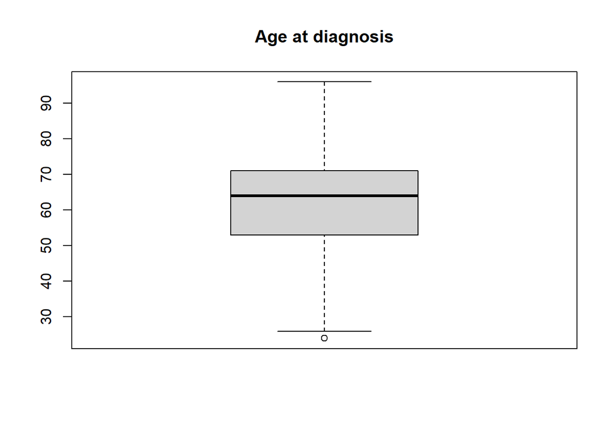

```r
boxplot(meta$age.at.diagnosis.ch1, main="Age at diagnosis")
```

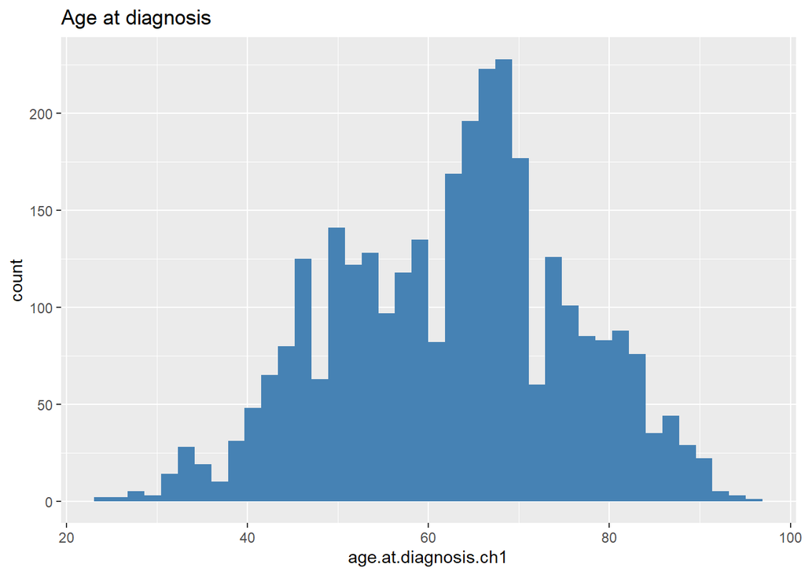

```r
ggplot(meta, aes(age.at.diagnosis.ch1)) +
  geom_histogram(bins = 40, fill = "steelblue") +
  labs(title = "Age at diagnosis")
```

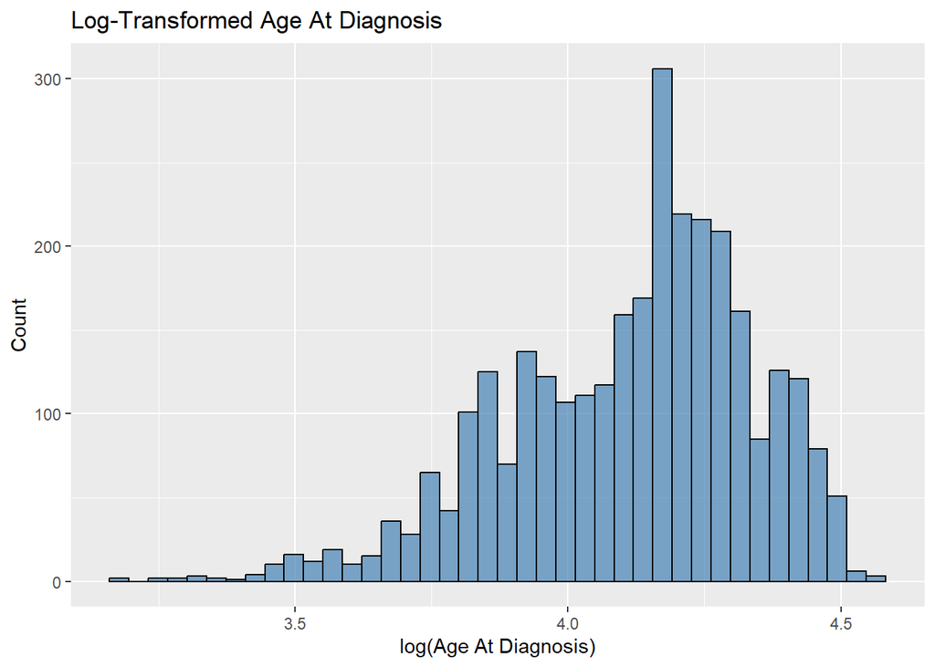

```r
# log transformation of the age distribution:
ggplot(meta, aes(x = log(age.at.diagnosis.ch1))) +
  geom_histogram(bins = 40, fill = "steelblue", color = "black", alpha = 0.7) +
  labs(title = "Log-Transformed Age At Diagnosis",
       x = "log(Age At Diagnosis)", y = "Count")
```

*distribution of tumor size distribution*

```r
summary(meta$tumor.size.ch1)
```

```
##    Min. 1st Qu.  Median    Mean 3rd Qu.    Max.    NA's
##    0.00   12.00   17.00   19.98   24.00  126.00      32
```

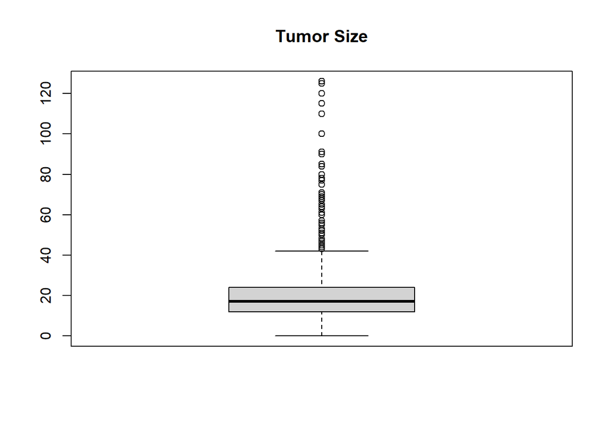

```r
boxplot(meta$tumor.size.ch1, main="Tumor Size")
```

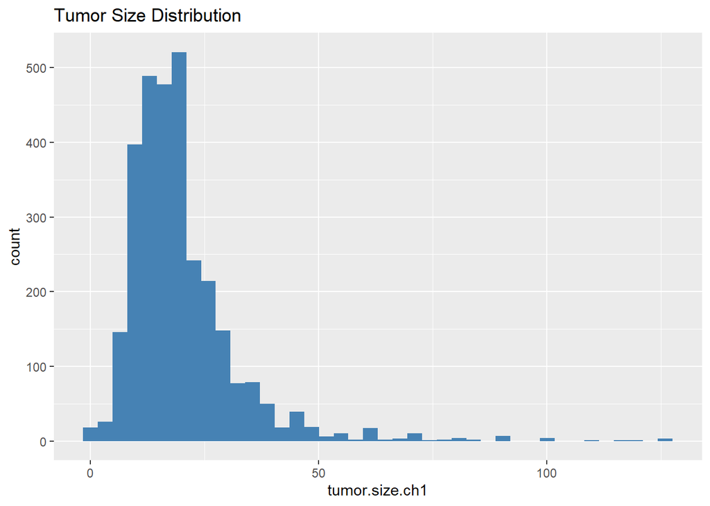

```r
ggplot(meta, aes(tumor.size.ch1)) +
  geom_histogram(bins = 40, fill = "steelblue") +
  labs(title = "Tumor Size Distribution")
```

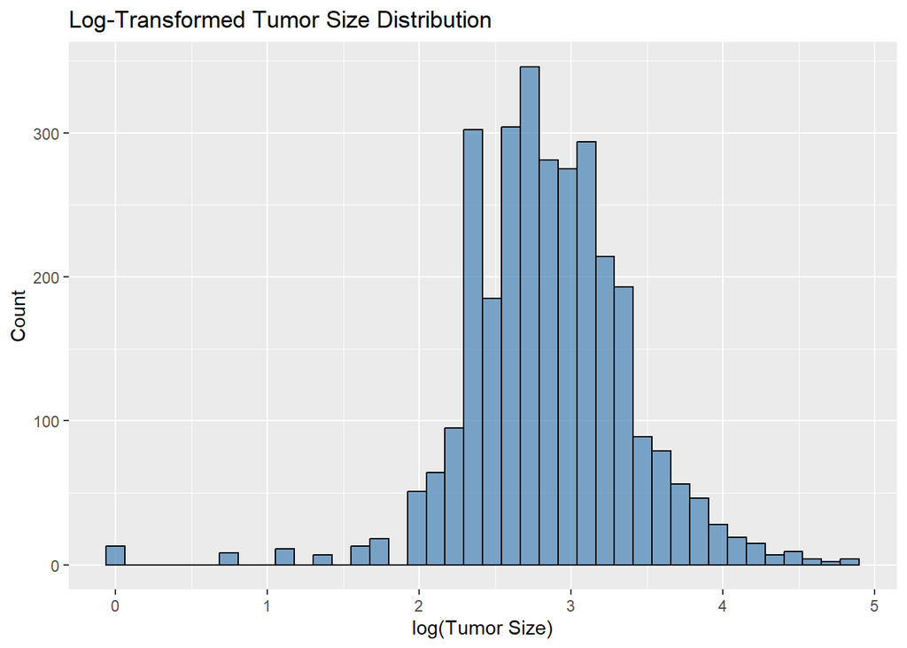

```r
# log transformation of the tumor size:
ggplot(meta, aes(x = log(tumor.size.ch1))) +
  geom_histogram(bins = 40, fill = "steelblue", color = "black", alpha = 0.7) +
  labs(title = "Log-Transformed Tumor Size Distribution",
       x = "log(Tumor Size)", y = "Count")
```

*distribution of overall survival*

```r
summary(meta$overall.survival.days.ch1)
```

```
##    Min. 1st Qu.  Median    Mean 3rd Qu.    Max.
##      56    1236    1612    1606    2004    2474
```

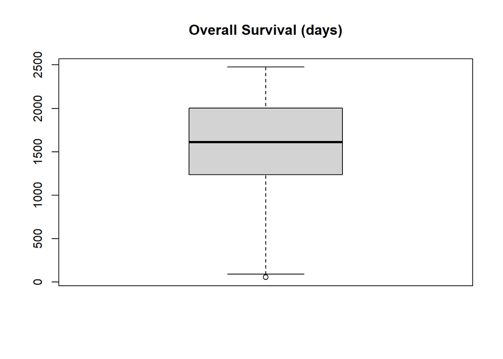

```r
boxplot(meta$overall.survival.days.ch1, main="Overall Survival (days)")
```

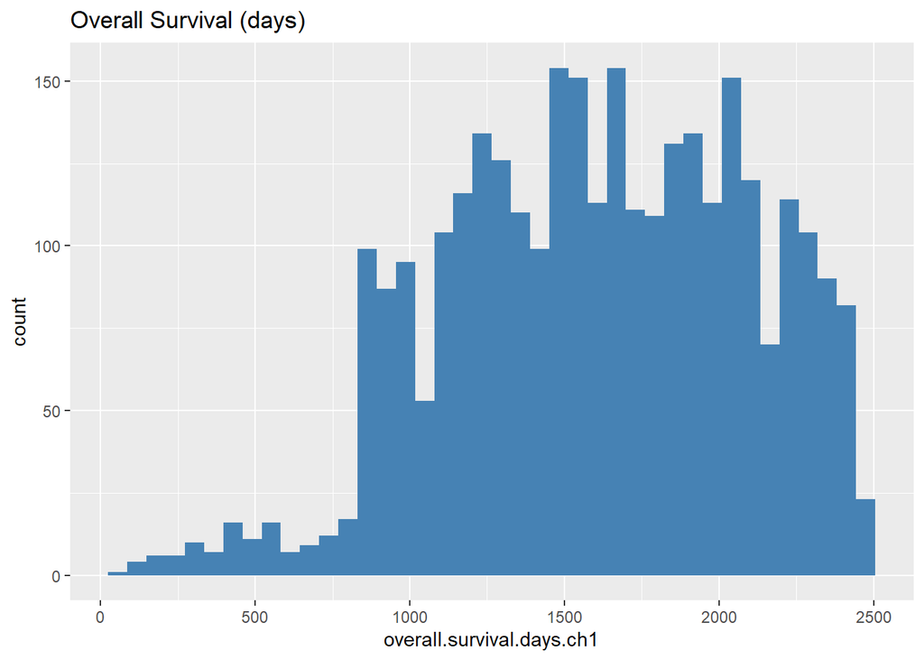

```r
ggplot(meta, aes(overall.survival.days.ch1)) +
  geom_histogram(bins = 40, fill = "steelblue") +
  labs(title = "Overall Survival (days)")
```

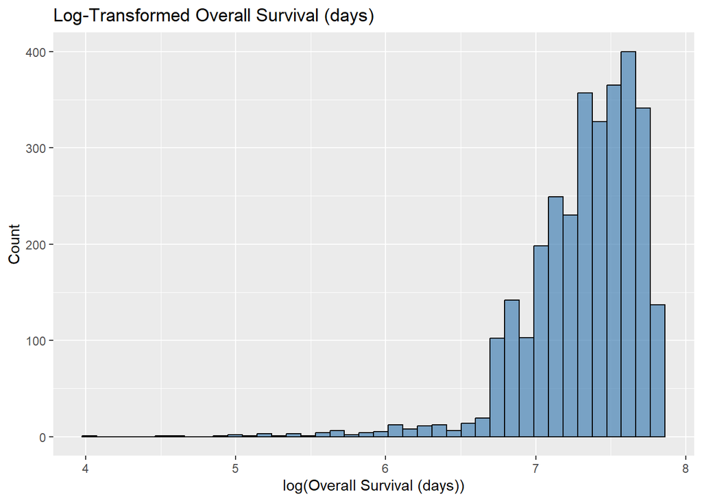

```r
ggplot(meta, aes(x = log(overall.survival.days.ch1))) +
  geom_histogram(bins = 40, fill = "steelblue", color = "black", alpha = 0.7) +
  labs(title = "Log-Transformed Overall Survival (days)",
       x = "log(Overall Survival (days))", y = "Count")
```

*distribution of PAM50*

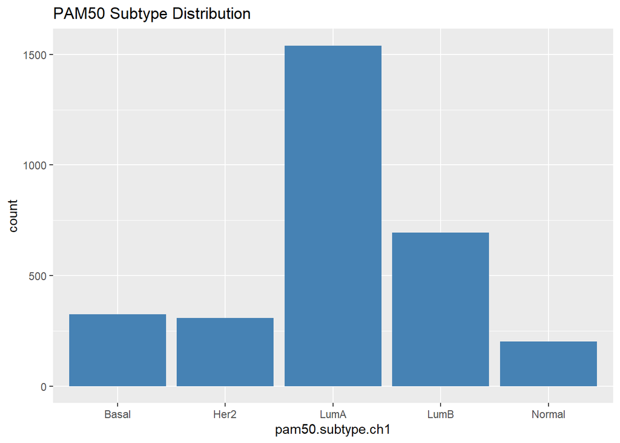

```r
ggplot(meta, aes(pam50.subtype.ch1)) +
  geom_bar(fill = "steelblue") +
  labs(title = "PAM50 Subtype Distribution")
```

*distribution of ER status*

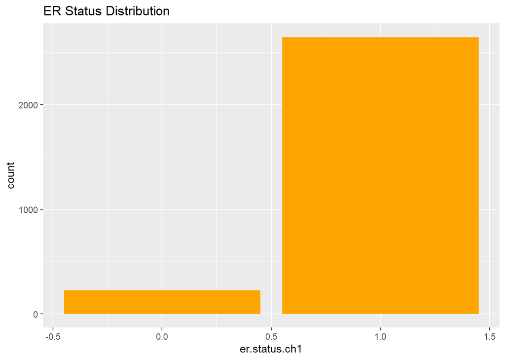

```r
# ER status distribution
ggplot(meta, aes(er.status.ch1)) +
  geom_bar(fill = "orange") +
  labs(title = "ER Status Distribution")
```

## outliers

*tumor size*

```r
#according to IQR method:
qs <- quantile(meta$tumor.size.ch1, c(.25, .75), na.rm = TRUE)
iqr <- qs[2] - qs[1]
lower <- qs[1] - 1.5 * iqr
upper <- qs[2] + 1.5 * iqr
meta$tumor_outlier <- ifelse(meta$tumor.size.ch1 < lower | meta$tumor.size.ch1 > upper, TRUE, FALSE)
print(table(meta$tumor_outlier))
```

```
##
## FALSE  TRUE
##  2899   138
```

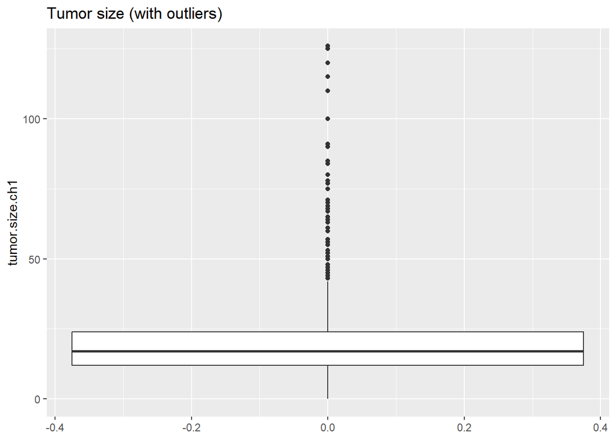

```r
#Plots
p1 <- ggplot(meta, aes(y = tumor.size.ch1)) +
  geom_boxplot() +
  labs(title = "Tumor size (with outliers)")
p2 <- ggplot(meta, aes(x = tumor.size.ch1)) +
  geom_histogram(bins = 40)
p3 <- ggplot(meta, aes(x = log1p(tumor.size.ch1))) +
  geom_histogram(bins = 40)
p1 #boxplot
```

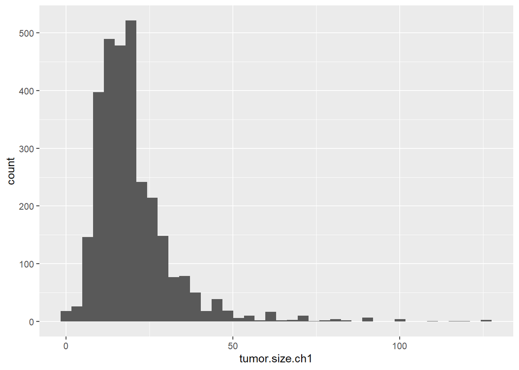

```r
p2 #histogram
```

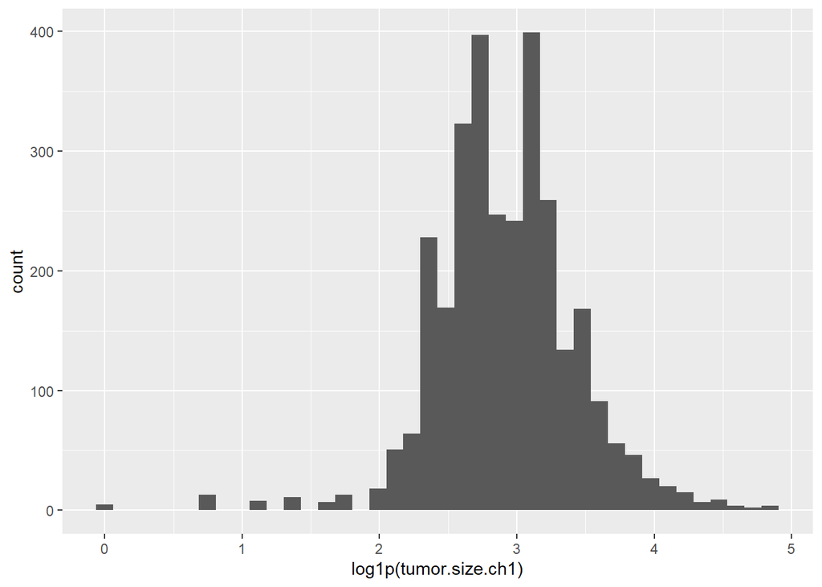

```r
p3 #log-transformed histogram
```

*overall survival*

```r
qs <- quantile(meta$overall.survival.days.ch1, c(.25, .75), na.rm = TRUE)
iqr <- qs[2] - qs[1]
lower <- qs[1] - 1.5 * iqr
upper <- qs[2] + 1.5 * iqr
meta$survival_outlier <- ifelse(meta$overall.survival.days.ch1 < lower | meta$overall.survival.days.ch1 > upper, TRUE, FALSE)
print(table(meta$survival_outlier))
```

```
##
## FALSE  TRUE
##  3068     1
```

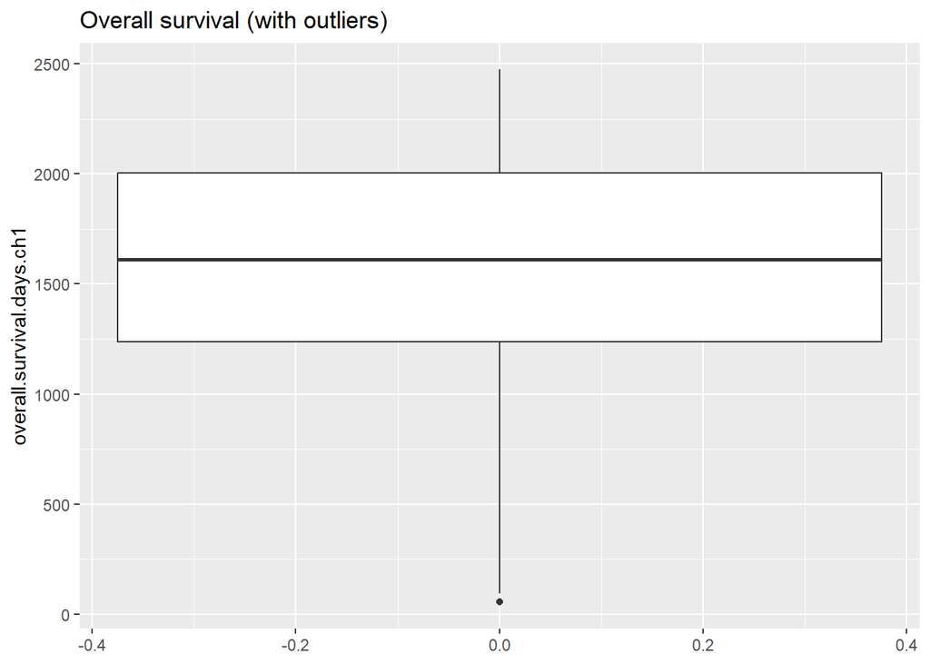

```r
#Plots
p1 <- ggplot(meta, aes(y = overall.survival.days.ch1)) + geom_boxplot() + labs(title = "Overall survival (with outliers)")
p2 <- ggplot(meta, aes(x = overall.survival.days.ch1)) + geom_histogram(bins = 40)
p3 <- ggplot(meta, aes(x = log1p(overall.survival.days.ch1))) + geom_histogram(bins = 40)
p1
```

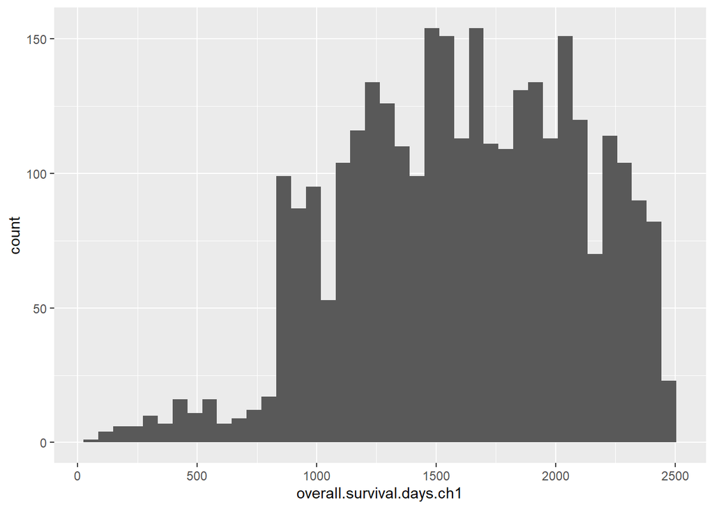

```r
p2
```

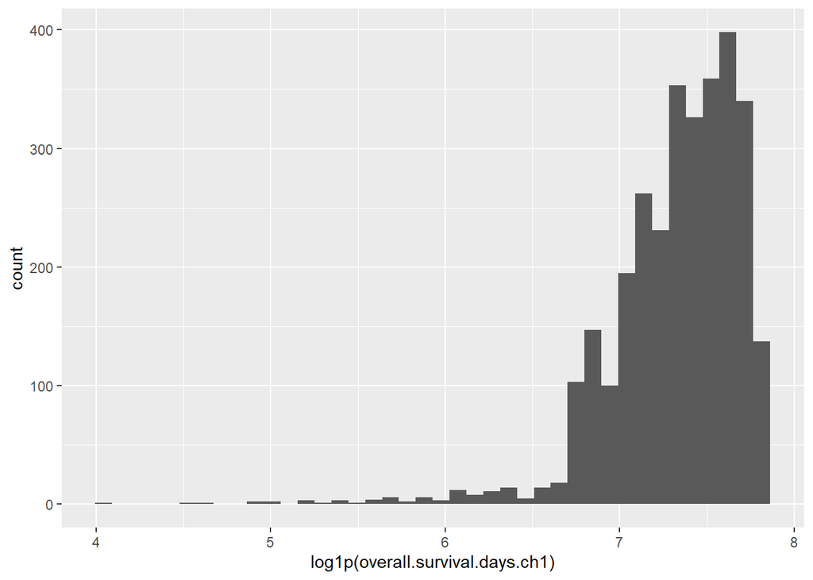

```r
p3
```

*age at diagnosis*

```r
qs <- quantile(meta$age.at.diagnosis.ch1, c(.25, .75), na.rm = TRUE)
iqr <- qs[2] - qs[1]
lower <- qs[1] - 1.5 * iqr
upper <- qs[2] + 1.5 * iqr
meta$age_outlier <- ifelse(meta$age.at.diagnosis.ch1 < lower | meta$age.at.diagnosis.ch1 > upper, TRUE, FALSE)
print(table(meta$age_outlier))
```

```
##
## FALSE  TRUE
##  3067     2
```

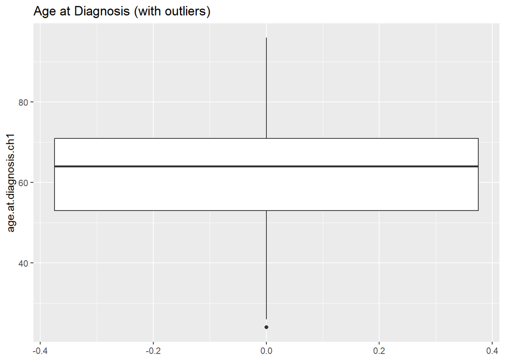

```r
p1 <- ggplot(meta, aes(y = age.at.diagnosis.ch1)) +
  geom_boxplot() +
  labs(title = "Age at Diagnosis (with outliers)")

# Histogram of original ages
p2 <- ggplot(meta, aes(x = age.at.diagnosis.ch1)) +
  geom_histogram(bins = 40) +
  labs(title = "Histogram of Age at Diagnosis")

# Histogram of log-transformed ages
p3 <- ggplot(meta, aes(x = log1p(age.at.diagnosis.ch1))) +
  geom_histogram(bins = 40) +
  labs(title = "Log-Transformed Age at Diagnosis")

p1
```

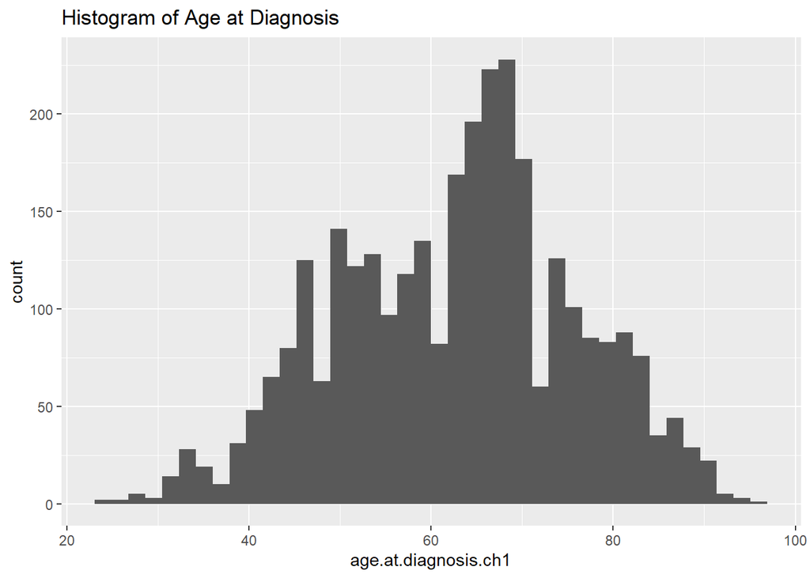

```r
p2
```

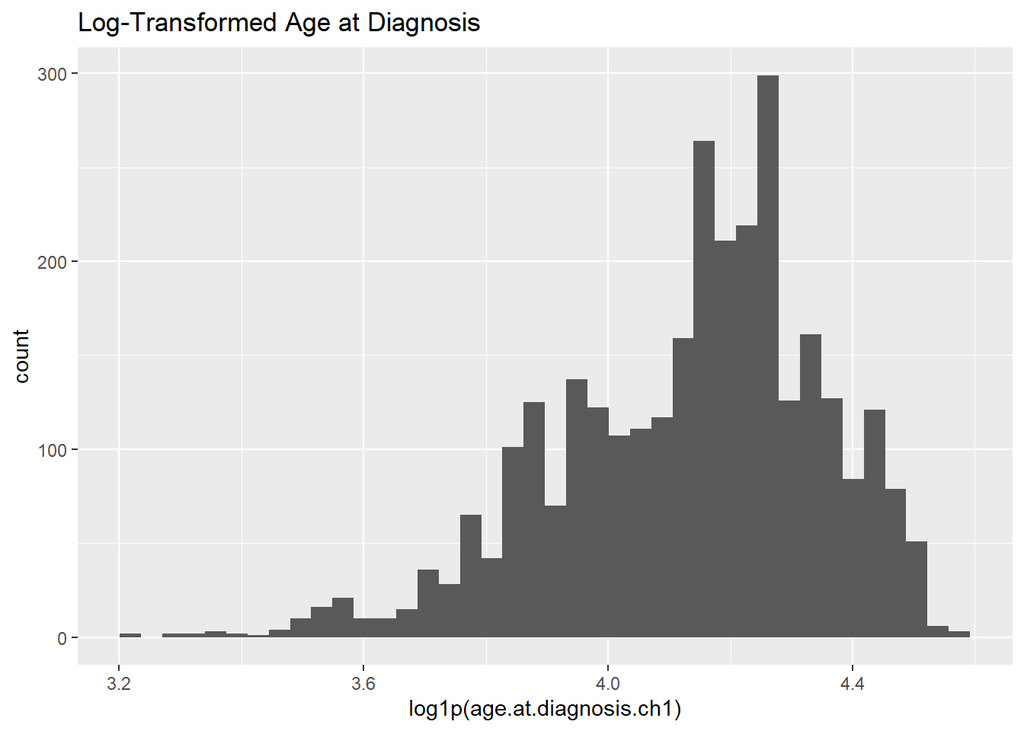

```r
p3
```

## missing values

```r
library(tibble)
library(ggplot2)
library(dplyr)

any(is.na(df))
```

```
## [1] FALSE
```

```r
any(is.na(meta))
```

```
## [1] TRUE
```

```r
colSums(is.na(meta))     # Missing values per column
```

```
##                  sample_id                      title
##                          0                          0
##              geo_accession                       type
##                          0                          0
##              channel_count            source_name_ch1
##                          0                          0
##       age.at.diagnosis.ch1          chemo.treated.ch1
##                          0                         21
##      endocrine.treated.ch1      er.prediction.mgc.ch1
##                         22                          0
##      er.prediction.sgc.ch1              er.status.ch1
##                          0                        199
##    her2.prediction.mgc.ch1    her2.prediction.sgc.ch1
##                          0                          0
##            her2.status.ch1       instrument.model.ch1
##                        105                          0
##    ki67.prediction.mgc.ch1    ki67.prediction.sgc.ch1
##                          0                          0
##            ki67.status.ch1       lymph.node.group.ch1
##                       1682                         96
##      lymph.node.status.ch1     nhg.prediction.mgc.ch1
##                         96                          0
##                    nhg.ch1  overall.survival.days.ch1
##                         61                          0
## overall.survival.event.ch1          pam50.subtype.ch1
##                          0                          0
##     pgr.prediction.mgc.ch1     pgr.prediction.sgc.ch1
##                          0                          0
##             pgr.status.ch1     scan.b.external.id.ch1
##                        330                          0
##             tumor.size.ch1              tumor_outlier
##                         32                         32
##           survival_outlier                age_outlier
##                          0                          0
```

```r
sum(is.na(meta))         # Total missing values
```

```
## [1] 2676
```

```r
#calculate percentage of missingness
miss_table <- tibble(variable = names(meta),
                     n_missing = sapply(meta, function(x) sum(is.na(x))),
                     pct_missing = 100 * sapply(meta, function(x) sum(is.na(x))) / nrow(meta)) %>%
  arrange(desc(pct_missing))
print(miss_table)
```

```
## # A tibble: 34 × 3
##    variable              n_missing pct_missing
##    <chr>                     <int>       <dbl>
##  1 ki67.status.ch1            1682      54.8
##  2 pgr.status.ch1              330      10.8
##  3 er.status.ch1               199       6.48
##  4 her2.status.ch1             105       3.42
##  5 lymph.node.group.ch1         96       3.13
##  6 lymph.node.status.ch1        96       3.13
##  7 nhg.ch1                      61       1.99
##  8 tumor.size.ch1               32       1.04
##  9 tumor_outlier                32       1.04
## 10 endocrine.treated.ch1        22       0.717
## # ℹ 24 more rows
```

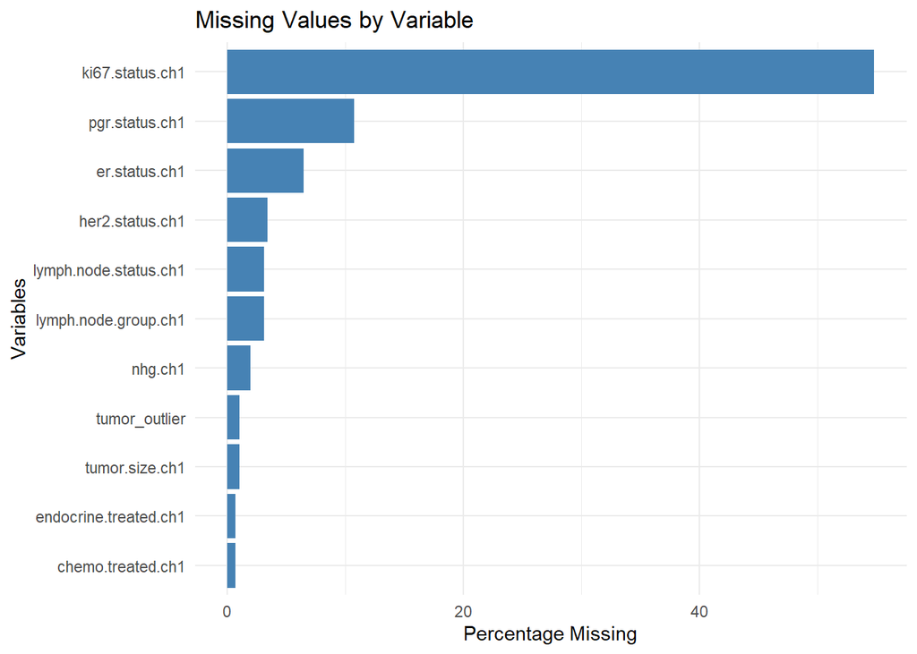

```r
# Plot missing values
miss_plot <- miss_table %>%
  filter(pct_missing > 0) %>%       # keep only variables with missing values
  arrange(desc(pct_missing))

ggplot(miss_plot, aes(x = pct_missing, y = reorder(variable, pct_missing))) +
  geom_bar(stat = "identity", fill = "steelblue") +
  labs(
    x = "Percentage Missing",
    y = "Variables",
    title = "Missing Values by Variable"
  ) +
  theme_minimal()
```

### determining type of missingness

```r
vars_to_check <- c("er.status.ch1", "pgr.status.ch1", "her2.status.ch1",
                   "tumor.size.ch1", "age.at.diagnosis.ch1", "overall.survival.days.ch1",
                   "chemo.treated.ch1", "endocrine.treated.ch1")

# Loop through variables
for(var in vars_to_check) {
  missing_col <- paste0(var, "_missing")
  meta[[missing_col]] <- is.na(meta[[var]])

  # Only fit GLM if some missing values exist
  if(sum(meta[[missing_col]]) > 0) {
    glm_model <- glm(
      formula = as.formula(paste(missing_col, "~ age.at.diagnosis.ch1 + tumor.size.ch1 + er.status.ch1 + pam50.subtype.ch1")),
      data = meta,
      family = binomial
    )
    cat("\n=== Missingness for:", var, "===\n")
    print(summary(glm_model))
  } else {
    cat("\n=== Missingness for:", var, "=== No missing values ===\n")
  }
}
```

```
##
## === Missingness for: er.status.ch1 ===
##
## Call:
## glm(formula = as.formula(paste(missing_col, "~ age.at.diagnosis.ch1 + tumor.size.ch1 + er.status.ch1 + pam50.subtype.ch1")),
##     family = binomial, data = meta)
##
## Coefficients:
##                           Estimate Std. Error z value Pr(>|z|)
## (Intercept)             -2.657e+01  4.189e+04  -0.001    0.999
## age.at.diagnosis.ch1     5.998e-15  5.230e+02   0.000    1.000
## tumor.size.ch1           9.696e-16  5.568e+02   0.000    1.000
## er.status.ch1           -3.436e-15  3.327e+04   0.000    1.000
## pam50.subtype.ch1Her2   -2.353e-14  3.599e+04   0.000    1.000
## pam50.subtype.ch1LumA   -1.494e-13  3.355e+04   0.000    1.000
## pam50.subtype.ch1LumB   -4.416e-14  3.518e+04   0.000    1.000
## pam50.subtype.ch1Normal -2.041e-14  4.042e+04   0.000    1.000
##
## (Dispersion parameter for binomial family taken to be 1)
##
##     Null deviance: 0.0000e+00  on 2846  degrees of freedom
## Residual deviance: 1.6517e-08  on 2839  degrees of freedom
##   (222 observations deleted due to missingness)
## AIC: 16
##
## Number of Fisher Scoring iterations: 25
##
##
## === Missingness for: pgr.status.ch1 ===
##
## Call:
## glm(formula = as.formula(paste(missing_col, "~ age.at.diagnosis.ch1 + tumor.size.ch1 + er.status.ch1 + pam50.subtype.ch1")),
##     family = binomial, data = meta)
##
## Coefficients:
##                           Estimate Std. Error z value Pr(>|z|)
## (Intercept)             -5.9452018  1.1111011  -5.351 8.76e-08 ***
## age.at.diagnosis.ch1     0.0087775  0.0069588   1.261  0.20718
## tumor.size.ch1           0.0007561  0.0073602   0.103  0.91817
## er.status.ch1            3.1452959  1.0293669   3.056  0.00225 **
```

[output cut: 29 more lines]

```
## pam50.subtype.ch1Her2   -0.450006   0.610752  -0.737    0.461
## pam50.subtype.ch1LumA    0.251852   0.534260   0.471    0.637
## pam50.subtype.ch1LumB   -0.190561   0.577577  -0.330    0.741
## pam50.subtype.ch1Normal  0.409994   0.600488   0.683    0.495
## ---
## Signif. codes:  0 '***' 0.001 '**' 0.01 '*' 0.05 '.' 0.1 ' ' 1
##
## (Dispersion parameter for binomial family taken to be 1)
##
##     Null deviance: 812.53  on 2846  degrees of freedom
## Residual deviance: 806.33  on 2839  degrees of freedom
##   (222 observations deleted due to missingness)
## AIC: 822.33
##
## Number of Fisher Scoring iterations: 6
```

```
##
## === Missingness for: tumor.size.ch1 ===
##
## Call:
## glm(formula = as.formula(paste(missing_col, "~ age.at.diagnosis.ch1 + tumor.size.ch1 + er.status.ch1 + pam50.subtype.ch1")),
##     family = binomial, data = meta)
##
## Coefficients:
##                           Estimate Std. Error z value Pr(>|z|)
## (Intercept)             -2.657e+01  4.189e+04  -0.001    0.999
## age.at.diagnosis.ch1     5.998e-15  5.230e+02   0.000    1.000
## tumor.size.ch1           9.696e-16  5.568e+02   0.000    1.000
## er.status.ch1           -3.436e-15  3.327e+04   0.000    1.000
## pam50.subtype.ch1Her2   -2.353e-14  3.599e+04   0.000    1.000
## pam50.subtype.ch1LumA   -1.494e-13  3.355e+04   0.000    1.000
## pam50.subtype.ch1LumB   -4.416e-14  3.518e+04   0.000    1.000
## pam50.subtype.ch1Normal -2.041e-14  4.042e+04   0.000    1.000
##
## (Dispersion parameter for binomial family taken to be 1)
##
##     Null deviance: 0.0000e+00  on 2846  degrees of freedom
## Residual deviance: 1.6517e-08  on 2839  degrees of freedom
##   (222 observations deleted due to missingness)
## AIC: 16
##
## Number of Fisher Scoring iterations: 25
##
##
## === Missingness for: age.at.diagnosis.ch1 === No missing values ===
##
## === Missingness for: overall.survival.days.ch1 === No missing values ===
##
## === Missingness for: chemo.treated.ch1 ===
##
## Call:
## glm(formula = as.formula(paste(missing_col, "~ age.at.diagnosis.ch1 + tumor.size.ch1 + er.status.ch1 + pam50.subtype.ch1")),
##     family = binomial, data = meta)
##
## Coefficients:
##                         Estimate Std. Error z value Pr(>|z|)
```

[output cut: 33 more lines]

```
## pam50.subtype.ch1Her2    0.23207    0.85375   0.272   0.7858
## pam50.subtype.ch1LumA    1.28075    1.05759   1.211   0.2259
## pam50.subtype.ch1LumB    0.42420    1.24133   0.342   0.7326
## pam50.subtype.ch1Normal  1.21342    1.02417   1.185   0.2361
## ---
## Signif. codes:  0 '***' 0.001 '**' 0.01 '*' 0.05 '.' 0.1 ' ' 1
##
## (Dispersion parameter for binomial family taken to be 1)
##
##     Null deviance: 228.24  on 2846  degrees of freedom
## Residual deviance: 202.95  on 2839  degrees of freedom
##   (222 observations deleted due to missingness)
## AIC: 218.95
##
## Number of Fisher Scoring iterations: 8
```

## pre-processing

### factorisation

```r
meta_clean <- meta %>%
  mutate(er_status = factor(ifelse(er.status.ch1 == 1, "Positive",
                                   ifelse(er.status.ch1 == 0, "Negative", NA))),
         pgr_status = factor(ifelse(pgr.status.ch1 == 1, "Positive",
                                    ifelse(pgr.status.ch1 == 0, "Negative", NA))),
         her2_status = factor(ifelse(her2.status.ch1 == 1, "Positive",
                                     ifelse(her2.status.ch1 == 0, "Negative", NA))),
         ki67_status = factor(ifelse(ki67.status.ch1 == 1, "High",
                                     ifelse(ki67.status.ch1 == 0, "Low", NA))),
         chemo = factor(ifelse(chemo.treated.ch1 == 1, "Yes",
                               ifelse(chemo.treated.ch1 == 0, "No", NA))),
         endocrine = factor(ifelse(endocrine.treated.ch1 == 1, "Yes",
                                   ifelse(endocrine.treated.ch1 == 0, "No", NA))),
         nhg_ord = factor(nhg.ch1, levels = c("G1","G2","G3"), ordered = TRUE),
         pam50 = factor(pam50.subtype.ch1))
```

### missing values, outliers & filtering

```r
library(tidyverse)
library(tidyr)

#drop rows with NA in one or more specified columns
meta_clean <- meta_clean %>% drop_na(er.status.ch1, her2.status.ch1, tumor.size.ch1)

#remove rows if tumor_size=0
meta_clean$tumor_size <- ifelse(meta_clean$tumor.size.ch1 == 0, NA, meta_clean$tumor.size.ch1)

#exclude Ki67 columns from metadata
meta_clean <- meta_clean %>% select(-ki67.status.ch1, -ki67_status)
```

### normalisation

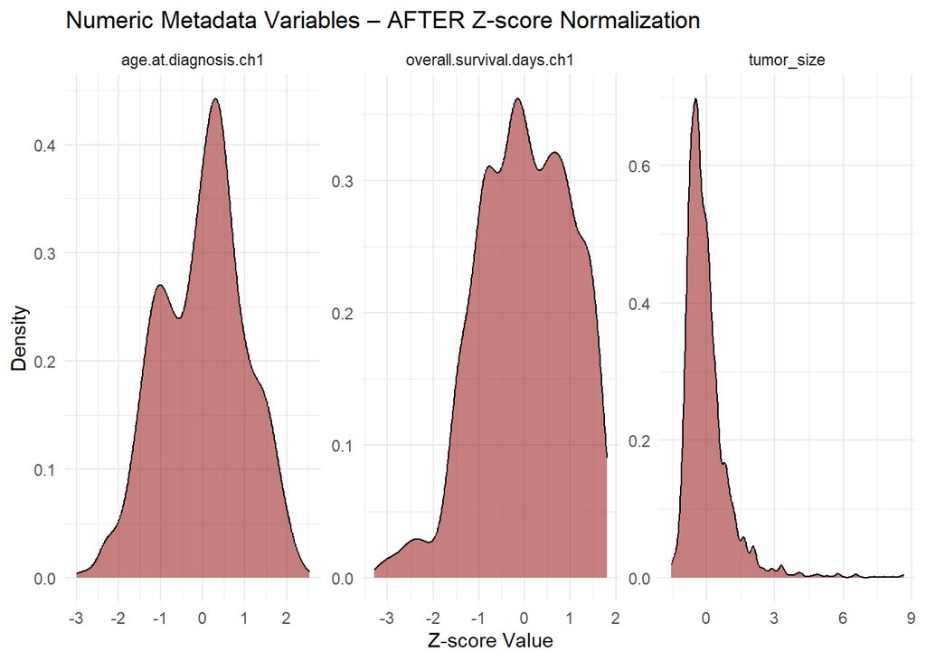

```r
# Define numeric variables for normalization
numeric_vars <- c("age.at.diagnosis.ch1", "tumor_size", "overall.survival.days.ch1")

# z-score normalisation
meta_scaled <- meta_clean
meta_scaled[numeric_vars] <- lapply(meta_clean[numeric_vars],
                                    function(x) {(x - mean(x, na.rm = TRUE)) / sd(x, na.rm = TRUE)})

#  Convert to long format safely
meta_long_after <- meta_scaled %>%
  select(all_of(numeric_vars)) %>%
  as.data.frame() %>%
  pivot_longer(cols = everything(),
               names_to = "variable",
               values_to = "value")

#  Plot
ggplot(meta_long_after, aes(x = value)) +
  geom_density(fill = "darkred", alpha = 0.5) +
  facet_wrap(~ variable, scales = "free") +
  theme_minimal() +
  labs(title = "Numeric Metadata Variables – AFTER Z-score Normalization",
       x = "Z-score Value", y = "Density")
```

### association tests

```r
# ==========================
# ASSOCIATION TESTS
# ==========================

# --- 1. Categorical vs Categorical (Chi-square) ---

# ER vs PGR
tab_er_pgr <- table(meta_clean$er_status, meta_clean$pgr_status)
cat("=== ER vs PGR ===\n")
```

```
## === ER vs PGR ===
```

```r
print(chisq.test(tab_er_pgr))
```

```
##
##  Pearson's Chi-squared test with Yates' continuity correction
##
## data:  tab_er_pgr
## X-squared = 1066.1, df = 1, p-value < 2.2e-16
```

```r
# ER vs HER2
tab_er_her2 <- table(meta_clean$er_status, meta_clean$her2_status)
cat("\n=== ER vs HER2 ===\n")
```

```
##
## === ER vs HER2 ===
```

```r
print(chisq.test(tab_er_her2))
```

```
##
##  Pearson's Chi-squared test with Yates' continuity correction
##
## data:  tab_er_her2
## X-squared = 38.22, df = 1, p-value = 6.32e-10
```

```r
# PGR vs HER2
tab_pgr_her2 <- table(meta_clean$pgr_status, meta_clean$her2_status)
cat("\n=== PGR vs HER2 ===\n")
```

```
##
## === PGR vs HER2 ===
```

```r
print(chisq.test(tab_pgr_her2))
```

```
##
##  Pearson's Chi-squared test with Yates' continuity correction
##
## data:  tab_pgr_her2
## X-squared = 79.123, df = 1, p-value < 2.2e-16
```

```r
# ER vs PAM50
tab_er_pam50 <- table(meta_clean$er_status, meta_clean$pam50)
cat("\n=== ER vs PAM50 ===\n")
```

```
##
## === ER vs PAM50 ===
```

```r
print(chisq.test(tab_er_pam50))
```

```
##
##  Pearson's Chi-squared test
##
## data:  tab_er_pam50
## X-squared = 1118.7, df = 4, p-value < 2.2e-16
```

```r
# PAM50 vs Chemo
tab_pam50_chemo <- table(meta_clean$pam50, meta_clean$chemo)
cat("\n=== PAM50 vs Chemo ===\n")
```

```
##
## === PAM50 vs Chemo ===
```

```r
print(chisq.test(tab_pam50_chemo))
```

```
##
##  Pearson's Chi-squared test
##
## data:  tab_pam50_chemo
## X-squared = 384.03, df = 4, p-value < 2.2e-16
```

```r
# PAM50 vs Endocrine therapy
tab_pam50_endocrine <- table(meta_clean$pam50, meta_clean$endocrine)
cat("\n=== PAM50 vs Endocrine therapy ===\n")
```

```
##
## === PAM50 vs Endocrine therapy ===
```

```r
print(chisq.test(tab_pam50_endocrine))
```

```
##
##  Pearson's Chi-squared test
##
## data:  tab_pam50_endocrine
## X-squared = 667.53, df = 4, p-value < 2.2e-16
```

```r
# --- 2. Numeric vs Categorical (Wilcoxon / Kruskal-Wallis) ---

# Tumor size ~ PAM50
cat("\n=== Tumor size ~ PAM50 ===\n")
```

```
##
## === Tumor size ~ PAM50 ===
```

```r
print(kruskal.test(tumor_size ~ pam50, data = meta_clean))
```

```
##
##  Kruskal-Wallis rank sum test
##
## data:  tumor_size by pam50
## Kruskal-Wallis chi-squared = 130.6, df = 4, p-value < 2.2e-16
```

```r
# Tumor size ~ ER
cat("\n=== Tumor size ~ ER ===\n")
```

```
##
## === Tumor size ~ ER ===
```

```r
print(wilcox.test(tumor_size ~ er_status, data = meta_clean))
```

```
##
##  Wilcoxon rank sum test with continuity correction
##
## data:  tumor_size by er_status
## W = 306797, p-value = 1.002e-05
## alternative hypothesis: true location shift is not equal to 0
```

```r
# Tumor size ~ HER2
cat("\n=== Tumor size ~ HER2 ===\n")
```

```
##
## === Tumor size ~ HER2 ===
```

```r
print(wilcox.test(tumor_size ~ her2_status, data = meta_clean))
```

```
##
##  Wilcoxon rank sum test with continuity correction
##
## data:  tumor_size by her2_status
## W = 368023, p-value = 0.006838
## alternative hypothesis: true location shift is not equal to 0
```

```r
# Age ~ PAM50
cat("\n=== Age ~ PAM50 ===\n")
```

```
##
## === Age ~ PAM50 ===
```

```r
print(kruskal.test(age.at.diagnosis.ch1 ~ pam50, data = meta_clean))
```

```
##
##  Kruskal-Wallis rank sum test
##
## data:  age.at.diagnosis.ch1 by pam50
## Kruskal-Wallis chi-squared = 42.897, df = 4, p-value = 1.087e-08
```

```r
# Age ~ ER
cat("\n=== Age ~ ER ===\n")
```

```
##
## === Age ~ ER ===
```

```r
print(wilcox.test(age.at.diagnosis.ch1 ~ er_status, data = meta_clean))
```

```
##
##  Wilcoxon rank sum test with continuity correction
##
## data:  age.at.diagnosis.ch1 by er_status
## W = 227079, p-value = 0.003391
## alternative hypothesis: true location shift is not equal to 0
```

```r
# Age ~ Chemo
cat("\n=== Age ~ Chemo ===\n")
```

```
##
## === Age ~ Chemo ===
```

```r
print(wilcox.test(age.at.diagnosis.ch1 ~ chemo, data = meta_clean))
```

```
##
##  Wilcoxon rank sum test with continuity correction
##
## data:  age.at.diagnosis.ch1 by chemo
## W = 1369416, p-value < 2.2e-16
## alternative hypothesis: true location shift is not equal to 0
```

```r
# Survival days ~ PAM50
cat("\n=== Overall survival ~ PAM50 ===\n")
```

```
##
## === Overall survival ~ PAM50 ===
```

```r
print(kruskal.test(overall.survival.days.ch1 ~ pam50, data = meta_clean))
```

```
##
##  Kruskal-Wallis rank sum test
##
## data:  overall.survival.days.ch1 by pam50
## Kruskal-Wallis chi-squared = 38.093, df = 4, p-value = 1.072e-07
```

```r
# --- 3. Numeric vs Numeric (Spearman correlation) ---

cat("\n=== Correlation: Age vs Tumor size ===\n")
```

```
##
## === Correlation: Age vs Tumor size ===
```

```r
print(cor.test(meta_clean$age.at.diagnosis.ch1, meta_clean$tumor_size, method = "spearman"))
```

```
##
##  Spearman's rank correlation rho
##
## data:  meta_clean$age.at.diagnosis.ch1 and meta_clean$tumor_size
## S = 3122337259, p-value = 1.051e-07
## alternative hypothesis: true rho is not equal to 0
## sample estimates:
##       rho
## 0.1011529
```

```r
cat("\n=== Correlation: Tumor size vs Survival days ===\n")
```

```
##
## === Correlation: Tumor size vs Survival days ===
```

```r
print(cor.test(meta_clean$tumor_size, meta_clean$overall.survival.days.ch1, method = "spearman"))
```

```
##
##  Spearman's rank correlation rho
##
## data:  meta_clean$tumor_size and meta_clean$overall.survival.days.ch1
## S = 3621182621, p-value = 0.02594
## alternative hypothesis: true rho is not equal to 0
## sample estimates:
##         rho
## -0.04245291
```

```r
cat("\n=== Correlation: Age vs Survival days ===\n")
```

```
##
## === Correlation: Age vs Survival days ===
```

```r
print(cor.test(meta_clean$age.at.diagnosis.ch1, meta_clean$overall.survival.days.ch1, method = "spearman"))
```

```
##
##  Spearman's rank correlation rho
##
## data:  meta_clean$age.at.diagnosis.ch1 and meta_clean$overall.survival.days.ch1
## S = 3765563681, p-value = 2.346e-05
## alternative hypothesis: true rho is not equal to 0
## sample estimates:
##         rho
## -0.08047941
```

# PART 2: FORMULATION OF 2 HYPOTHESES

## univariate research question

RQ1: Is there a difference in tumor size between the ER-positive and ER-negative groups?

*hypothesis:* • Null hypothesis (H0): There is no difference in mean tumor size between the ER-positive and ER-negative group. • Alternative hypothesis (H1): There is a difference in mean tumor size between the ER-positive and ER-negative group.

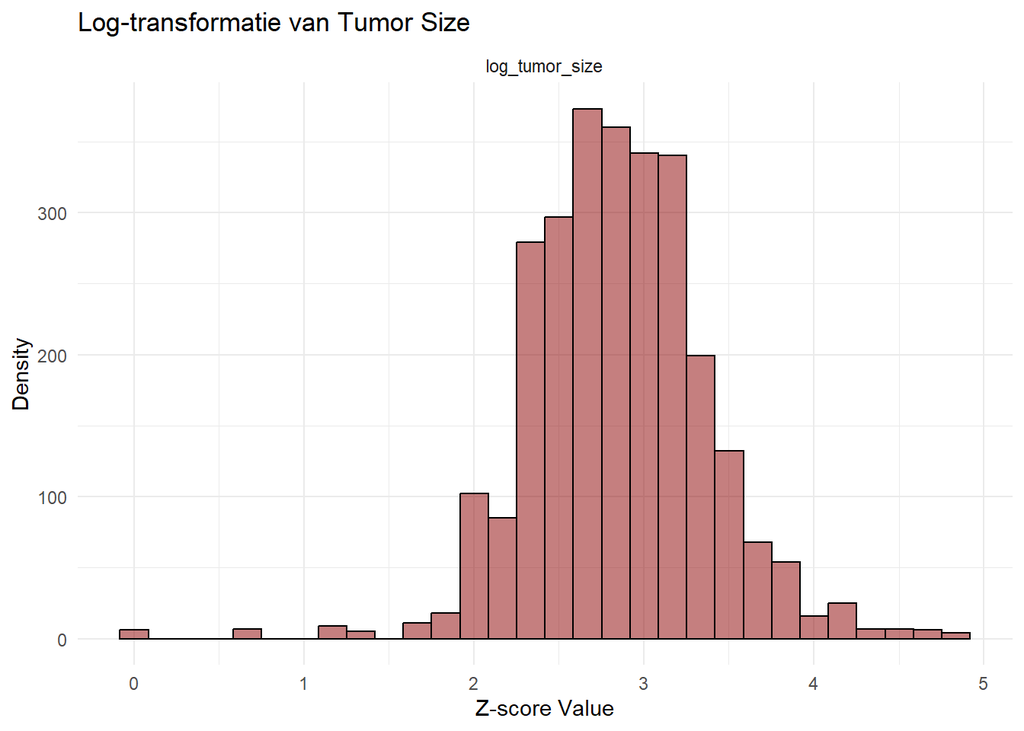

```r
meta_uni <- meta_clean %>%
  filter(!is.na(tumor.size.ch1), !is.na(pam50.subtype.ch1))

#log-transformation tumor size
meta_log <- meta_uni
meta_log$log_tumor_size <- log(meta_log$tumor_size)
meta_long_log <- meta_log %>%
  select(log_tumor_size) %>%
  as.data.frame() %>%
  pivot_longer(cols = everything(), names_to = "variable", values_to = "value")
ggplot(meta_long_log, aes(x = value)) +
  geom_histogram(fill = "darkred", alpha = 0.5, color = "black") +
  facet_wrap(~ variable, scales = "free") +
  theme_minimal() +
  labs(title = "Log-transformatie van Tumor Size", x = "Z-score Value", y = "Density")
```

```r
#t-test
t.test(tumor_size ~ er_status, data = meta_log)
```

```
##
##  Welch Two Sample t-test
##
## data:  tumor_size by er_status
## t = 3.5711, df = 223.18, p-value = 0.0004354
## alternative hypothesis: true difference in means between group Negative and group Positive is not equal to 0
## 95 percent confidence interval:
##  1.715879 5.941496
## sample estimates:
## mean in group Negative mean in group Positive
##               23.46305               19.63437
```

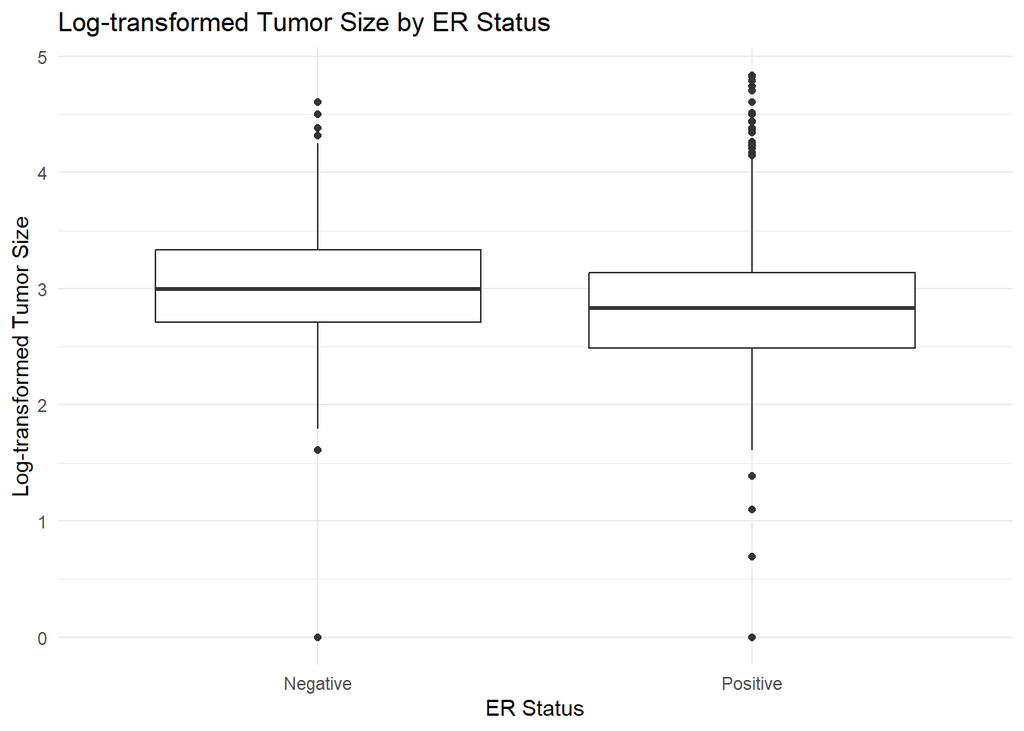

```r
#visualisation
ggplot(meta_log, aes(x = er_status, y = log_tumor_size)) +
  geom_boxplot() +
  theme_minimal() +
  labs(title = "Log-transformed Tumor Size by ER Status", x = "ER Status", y = "Log-transformed Tumor Size")
```

## multivariate research question

RQ2: Does the PAM50 subtype predict overall survival, even after adjusting for clinical covariates? - Dependent: Overall survival - Predictors: PAM50 + age + tumor size + lymph node status

*hypothesis:* • Null hypothesis (H0): Overall survival does not differ among the PAM50 molecular subtypes after adjusting for clinical covariates (age, tumor size, lymph node status). • Alternative hypothesis (H1): Overall survival differs among the PAM50 molecular subtypes after adjusting for clinical covariates (age, tumor size, lymph node status).

```r
library(survival)
library(survminer)
summary(meta$overall.survival.days.ch1)
```

```
##    Min. 1st Qu.  Median    Mean 3rd Qu.    Max.
##      56    1236    1612    1606    2004    2474
```

```r
summary(meta$overall.survival.event.ch1)
```

```
##    Min. 1st Qu.  Median    Mean 3rd Qu.    Max.
##  0.0000  0.0000  0.0000  0.1049  0.0000  1.0000
```

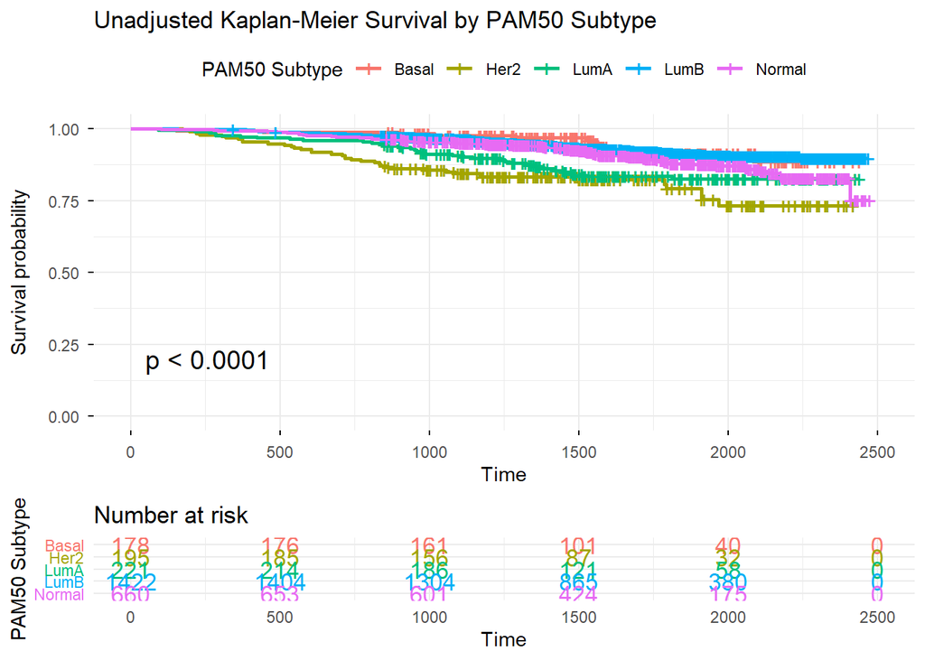

```r
#data set voorbereiden
meta_surv <- meta_clean %>%
  filter(!is.na(overall.survival.days.ch1),
         !is.na(overall.survival.event.ch1),
         !is.na(pam50.subtype.ch1),
         !is.na(tumor.size.ch1),
         !is.na(age.at.diagnosis.ch1),
         !is.na(lymph.node.status.ch1))
meta_surv$pam50.subtype.ch1 <- relevel(factor(meta_surv$pam50.subtype.ch1), ref = "Normal")

#survival object
surv_obj <- Surv(time = meta_surv$overall.survival.days.ch1,
                 event = meta_surv$overall.survival.event.ch1)

#unadjusted kaplan-meier curve
fit_km <- survfit(surv_obj ~ pam50.subtype.ch1, data = meta_surv)
ggsurvplot(fit_km,
           data = meta_surv,
           risk.table = TRUE,
           risk.table.col = "strata",
           pval = TRUE,
           ggtheme = theme_minimal(),
           title = "Unadjusted Kaplan-Meier Survival by PAM50 Subtype",
           legend.title = "PAM50 Subtype",
           legend.labs = c("Basal", "Her2", "LumA", "LumB", "Normal"))
```

*statistical test: cox model & visualisation: kaplan-meier curve*

```r
#cox h model
cox_model <- coxph(surv_obj ~ pam50.subtype.ch1 + age.at.diagnosis.ch1 + tumor.size.ch1 + lymph.node.status.ch1, data = meta_surv)
summary(cox_model)
```

```
## Call:
## coxph(formula = surv_obj ~ pam50.subtype.ch1 + age.at.diagnosis.ch1 +
##     tumor.size.ch1 + lymph.node.status.ch1, data = meta_surv)
##
##   n= 2676, number of events= 258
##
##                                       coef exp(coef) se(coef)      z Pr(>|z|)
## pam50.subtype.ch1Basal            1.633348  5.120991 0.345758  4.724 2.31e-06
## pam50.subtype.ch1Her2             0.907172  2.477308 0.350246  2.590  0.00959
## pam50.subtype.ch1LumA             0.224978  1.252295 0.319723  0.704  0.48164
## pam50.subtype.ch1LumB             0.428376  1.534762 0.327074  1.310  0.19029
## age.at.diagnosis.ch1              0.075488  1.078410 0.005854 12.895  < 2e-16
## tumor.size.ch1                    0.017434  1.017587 0.003109  5.607 2.05e-08
## lymph.node.status.ch1NodePositive 0.249467  1.283341 0.128413  1.943  0.05205
##
## pam50.subtype.ch1Basal            ***
## pam50.subtype.ch1Her2             **
## pam50.subtype.ch1LumA
## pam50.subtype.ch1LumB
## age.at.diagnosis.ch1              ***
## tumor.size.ch1                    ***
## lymph.node.status.ch1NodePositive .
## ---
## Signif. codes:  0 '***' 0.001 '**' 0.01 '*' 0.05 '.' 0.1 ' ' 1
##
##                                   exp(coef) exp(-coef) lower .95 upper .95
## pam50.subtype.ch1Basal                5.121     0.1953    2.6004    10.085
## pam50.subtype.ch1Her2                 2.477     0.4037    1.2470     4.922
## pam50.subtype.ch1LumA                 1.252     0.7985    0.6692     2.343
## pam50.subtype.ch1LumB                 1.535     0.6516    0.8084     2.914
## age.at.diagnosis.ch1                  1.078     0.9273    1.0661     1.091
## tumor.size.ch1                        1.018     0.9827    1.0114     1.024
## lymph.node.status.ch1NodePositive     1.283     0.7792    0.9978     1.651
##
## Concordance= 0.78  (se = 0.015 )
## Likelihood ratio test= 297  on 7 df,   p=<2e-16
## Wald test            = 294.5  on 7 df,   p=<2e-16
## Score (logrank) test = 332.7  on 7 df,   p=<2e-16
```

```r
#assumptions check
cox.zph(cox_model)
```

```
##                       chisq df      p
## pam50.subtype.ch1     12.41  4 0.0145
## age.at.diagnosis.ch1   3.44  1 0.0637
## tumor.size.ch1         1.57  1 0.2097
## lymph.node.status.ch1  0.04  1 0.8415
## GLOBAL                19.25  7 0.0074
```

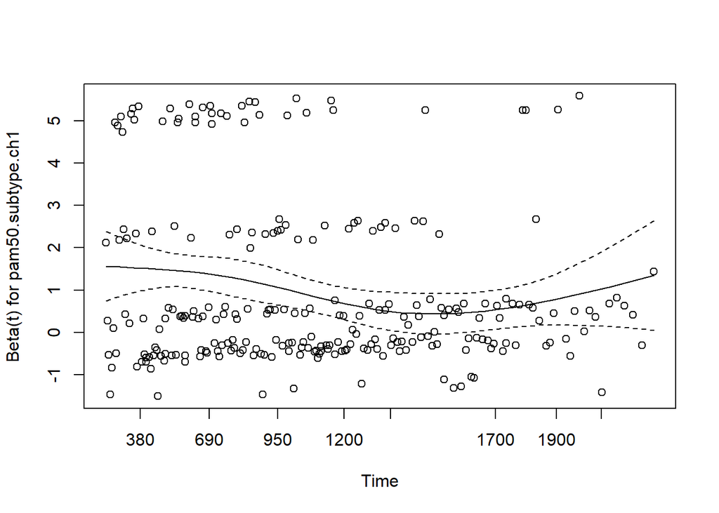

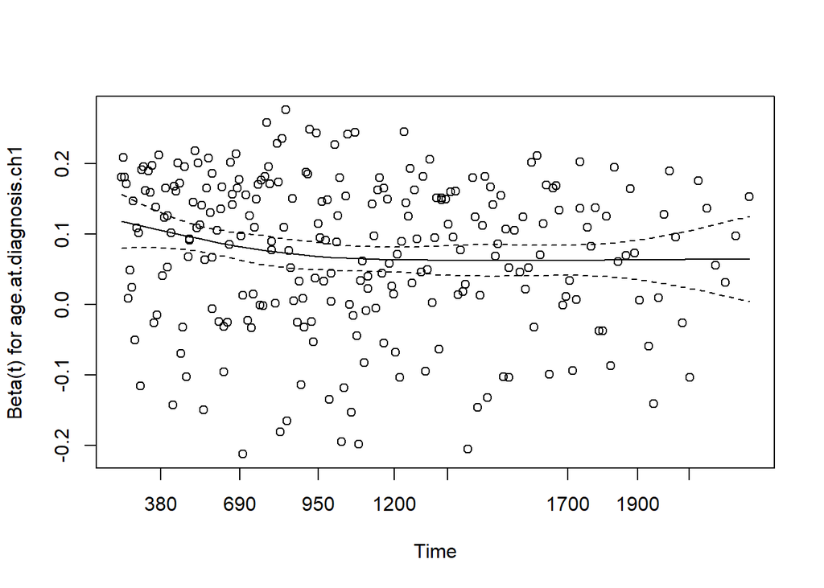

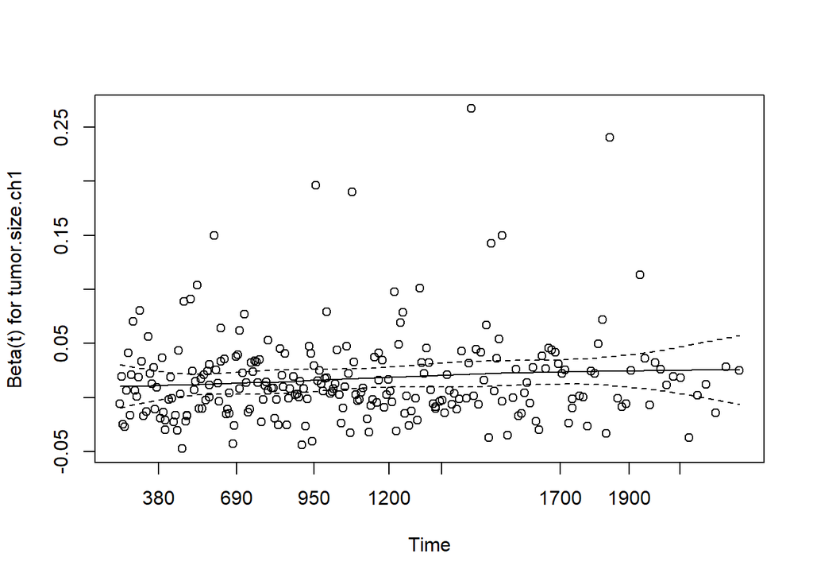

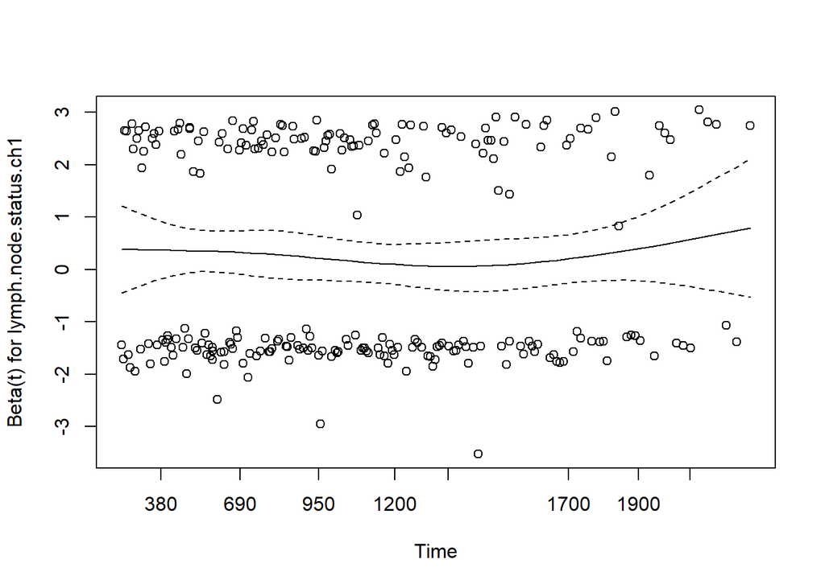

```r
plot(cox.zph(cox_model))
```

```
## Ignoring unknown labels:
## • fill : "PAM50 Subtype"
## • linetype : "PAM50 Subtype"
## • shape : "PAM50 Subtype"
```

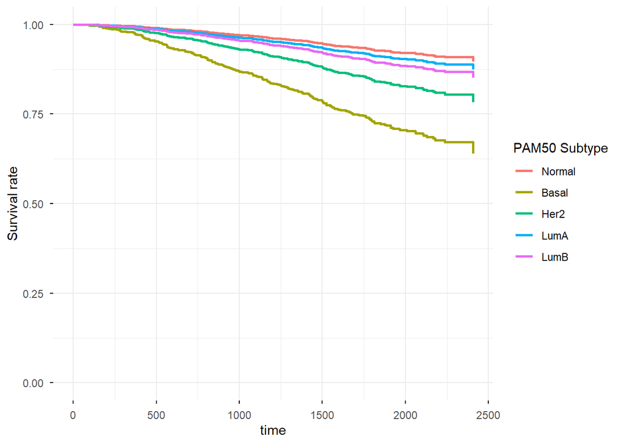

```r
# adjusted survival via cox model
ggadjustedcurves(cox_model,
                 data = meta_surv,
                 variable = "pam50.subtype.ch1",
                 ref = "Normal",
                 ggtheme = theme_minimal(),
                 labs = labs(title = "Adjusted Kaplan-Meier Survival by PAM50 Subtype", x="Time (days)"),
                 legend.title = "PAM50 Subtype",
                 legend.labs = c("Basal", "Her2", "LumA", "LumB", "Normal"))
```

**conclusion:** The PAM50 subtypes ‘Basal’ and ‘Her2’ have a significantly higher hazard of death compared to the ‘Normal’ PAM50 subtype, respectively 5.12 times higher (p=2.31e-06 ; 95% CI: [2.60, 10.085]) and 2.5 times higher (p=0.00959 ; 95% CI: [1.25,4.92]). There is no strong evidence of different hazard for the LumA and LumB subtypes (p > 0.05).